# Differential Expression Analysis in *Syngnathus floridae*

```r
#The abundance matrix generated via salmon and tximport to be used for the DE analysis
txi.salmon <- readRDS("data/txi.salmon.floride.RDS")

#The samples file generated for tximport
samples <- read.table("FL_samples.txt", header = TRUE)

#Make sure the conditions are in the samples file as a factor
samples$Sex <- as.factor(samples$Sex)
samples$Organ <- as.factor(samples$Organ)

#Adding in Mating success and Rep fitness(total number of eggs transferred)
samples$mate_success <- c("1", "1", "3", "1", "2", "2", "1", "2", "0",
                          "1", "1", "3", "3", "1", "2", "2", "1", "2", "0",
                          "1", "1", "3", "3", "0",
                          "1", "1", "2", "1", "1")

samples$rep_fittness <- c(169, 88, 762, 285, 467, 500, 427, 156, 0,
                          169, 88, 762, 916, 285, 467, 500, 427, 156, 0,
                          169, 88, 762, 916, 0,
                          159, 285, 156, 372, 166)
```

The package `DESeq2` was used for the differential expression analysis outlined below.

# 1 Single factor analysis - Comparing Males v Females

To analyze your data with DESeq2 you must first generate the DESeqDataSet. In order to do this we need the abundance matrix generated with `tximport` and a `samples` file that lays out all of the conditions.

```r
#Create the DESeq dataset
dds_FL <- DESeqDataSetFromTximport(txi.salmon,
                                   colData = samples,
                                   design = ~ Sex)
```

The data is then pre-filtered to remove low gene counts before running further DESeq2 functions. By doing this we remove rows in which there are very few reads thus reducing the memory size of the `dds` object and increasing the speed at which we can use the transformation and testing functions in DESeq2.

```r
#only keeping rows that have at lead 10 reads total
keep <- rowSums(counts(dds_FL)) >= 10
dds_FL <- dds_FL[keep, ]
```

After filtering we can now perform the standard differential expression analysis that is wrapped into DESeq2.

```r
#Generate the expression values
dds_FL_exp <- DESeq(dds_FL)

#Compile the results
res <- results(dds_FL_exp)
res
```

```
## log2 fold change (MLE): Sex M vs F
## Wald test p-value: Sex M vs F
## DataFrame with 175095 rows and 6 columns
##                        baseMean log2FoldChange     lfcSE       stat    pvalue
##                       <numeric>      <numeric> <numeric>  <numeric> <numeric>
## TRINITY_DN0_c0_g1     1801.1920      0.2673823  0.197183   1.356008  0.175097
## TRINITY_DN0_c0_g2     2573.3828      0.7634647  0.581650   1.312585  0.189323
## TRINITY_DN0_c1_g1        9.1754      0.9097093  0.530020   1.716367  0.086095
## TRINITY_DN1_c0_g1     1292.0108     -0.1941494  0.158366  -1.225957  0.220215
## TRINITY_DN1_c0_g2      114.9169     -0.0871335  0.419554  -0.207681  0.835478
## ...                         ...            ...       ...        ...       ...
## TRINITY_DN99992_c0_g1  1.308178      1.4606597  1.082334  1.3495467  0.177161
## TRINITY_DN99993_c0_g2  0.772193     -0.6254412  1.154951 -0.5415307  0.588142
## TRINITY_DN99995_c0_g1  1.277924     -0.0108875  0.780664 -0.0139464  0.988873
## TRINITY_DN99997_c0_g1  2.179808     -0.0575813  1.686240 -0.0341478  0.972759
## TRINITY_DN99999_c0_g1  0.251955      1.6312941  2.971355  0.5490068  0.583001
##                            padj
##                       <numeric>
## TRINITY_DN0_c0_g1      0.532694
## TRINITY_DN0_c0_g2      0.555717
## TRINITY_DN0_c1_g1      0.353179
## TRINITY_DN1_c0_g1      0.603156
## TRINITY_DN1_c0_g2      0.969274
## ...                         ...
## TRINITY_DN99992_c0_g1        NA
## TRINITY_DN99993_c0_g2        NA
## TRINITY_DN99995_c0_g1        NA
## TRINITY_DN99997_c0_g1  0.995694
## TRINITY_DN99999_c0_g1        NA
```

Once that has finished we can now start exploring some of the single-factor analysis results

```r
##Ordering our results based on p-value
resOrdered <- res[order(res$pvalue),]
resOrdered
```

```
## log2 fold change (MLE): Sex M vs F
## Wald test p-value: Sex M vs F
## DataFrame with 175095 rows and 6 columns
##                        baseMean log2FoldChange     lfcSE      stat      pvalue
##                       <numeric>      <numeric> <numeric> <numeric>   <numeric>
## TRINITY_DN3756_c0_g1   918.7630        28.7244   2.07255   13.8595 1.11511e-43
## TRINITY_DN21727_c0_g2   68.6867        25.1027   1.91953   13.0775 4.42515e-39
## TRINITY_DN7854_c0_g1   138.4769        26.0705   2.01975   12.9078 4.06857e-38
## TRINITY_DN31591_c0_g1   47.3757       -25.3123   2.08364  -12.1481 5.86888e-34
## TRINITY_DN25251_c0_g2   83.2229        23.9277   1.97962   12.0870 1.23683e-33
## ...                         ...            ...       ...       ...         ...
## TRINITY_DN99802_c0_g1         0              0         0         0           1
## TRINITY_DN99802_c0_g2         0              0         0         0           1
## TRINITY_DN99826_c0_g1         0              0         0         0           1
## TRINITY_DN99826_c0_g2         0              0         0         0           1
## TRINITY_DN99888_c0_g3         0              0         0         0           1
##                              padj
##                         <numeric>
## TRINITY_DN3756_c0_g1  7.46547e-39
## TRINITY_DN21727_c0_g2 1.48128e-34
## TRINITY_DN7854_c0_g1  9.07942e-34
## TRINITY_DN31591_c0_g1 9.82275e-30
## TRINITY_DN25251_c0_g2 1.65607e-29
## ...                           ...
## TRINITY_DN99802_c0_g1          NA
## TRINITY_DN99802_c0_g2          NA
## TRINITY_DN99826_c0_g1          NA
## TRINITY_DN99826_c0_g2          NA
## TRINITY_DN99888_c0_g3          NA
```

```r
summary(res)
```

```
##
## out of 167170 with nonzero total read count
## adjusted p-value < 0.1
## LFC > 0 (up)       : 4406, 2.6%
## LFC < 0 (down)     : 3698, 2.2%
## outliers [1]       : 0, 0%
## low counts [2]     : 108147, 65%
## (mean count < 2)
## [1] see 'cooksCutoff' argument of ?results
## [2] see 'independentFiltering' argument of ?results
```

```r
#How many ADJUSTED p-values were less than 0.1?
sum(res$padj < 0.1, na.rm = TRUE)
```

```
## [1] 8104
```

```r
#Looking at  an alpha=0.05, the default is 0.1
res05 <- results(dds_FL_exp, alpha = 0.05)
summary(res05)
```

```
##
## out of 167170 with nonzero total read count
## adjusted p-value < 0.05
## LFC > 0 (up)       : 3196, 1.9%
## LFC < 0 (down)     : 2729, 1.6%
## outliers [1]       : 0, 0%
## low counts [2]     : 111380, 67%
## (mean count < 2)
## [1] see 'cooksCutoff' argument of ?results
## [2] see 'independentFiltering' argument of ?results
```

```r
sum(res05$padj < 0.05, na.rm = TRUE)
```

```
## [1] 5925
```

## 1.1 Visualizing the results

### MA-plot - MvF Diff.

Generate an MA-plot to show the log2 fold changes attributable to sex over the mean of normalized counts for all of the samples in the `dds`. Points will be colored if the adjusted p-value is less that 0.1.

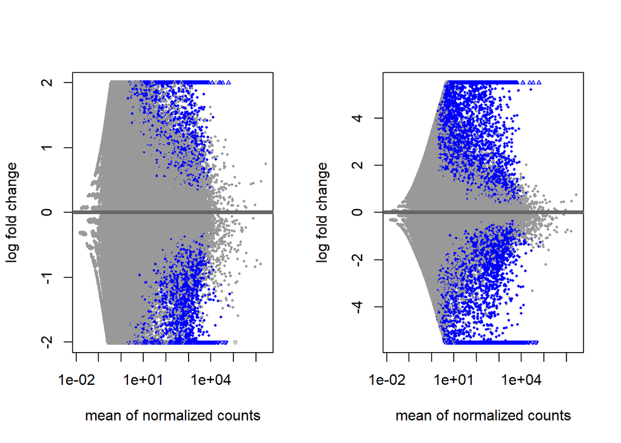

### Heatmap - overall expression

We can also generate a heat map to look ar overall expression levels across our samples. Note, this is not differentially expressed genes.

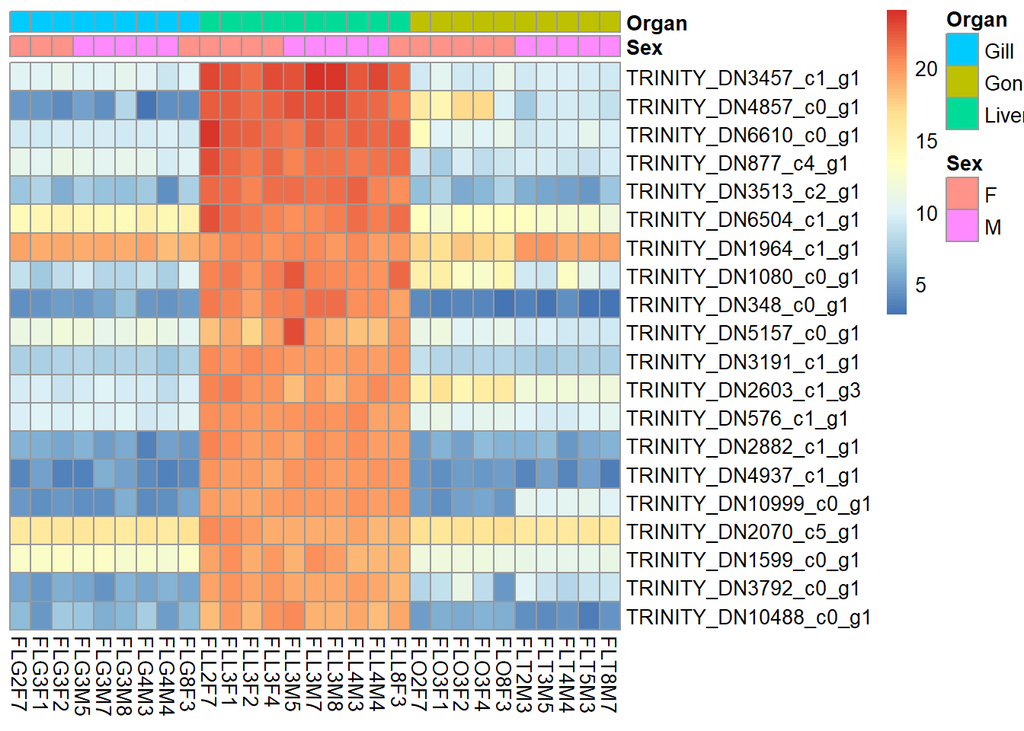

From the heatmap we can pull out the names of the Trinity genes that are showing this high expression and BLAST the corresponding sequences to see what the genes are.

```r
#Pull out the corresponding trinity_geneIDS that are plotted in the heatmap
heatmap_TG <- cbind(row.names(assay(vsd)[select,]))
write.table(heatmap_TG,
            'heatmap_trinitygenes.txt',
            sep = "",
            quote=FALSE,
            row.names = FALSE,
            col.names = FALSE)
```

### Sample-dist Heatmap

We can then generate a sample-to-sample distances heatmap that will give an overview of the similarities and differences between our samples

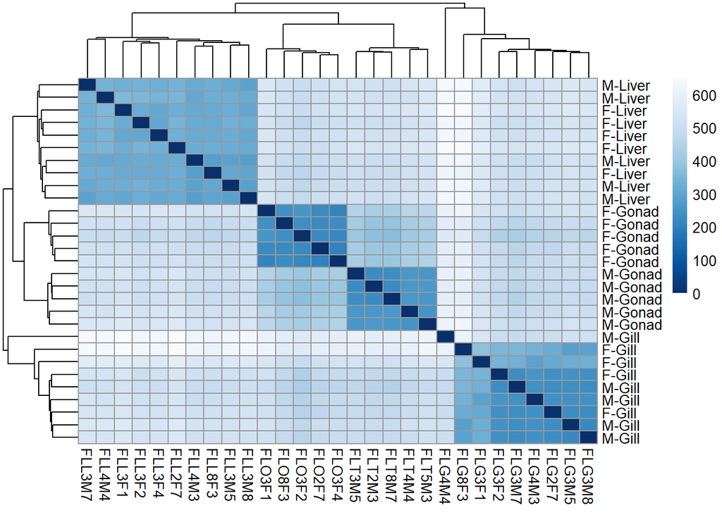

### PCA plots

```r
colData <- as.data.frame(samples)
rownames(colData) <- samples$ID

#Prepare the PCA using the transformed data from above
pcaFL <- pca(assay(vsd), metadata = colData)
```

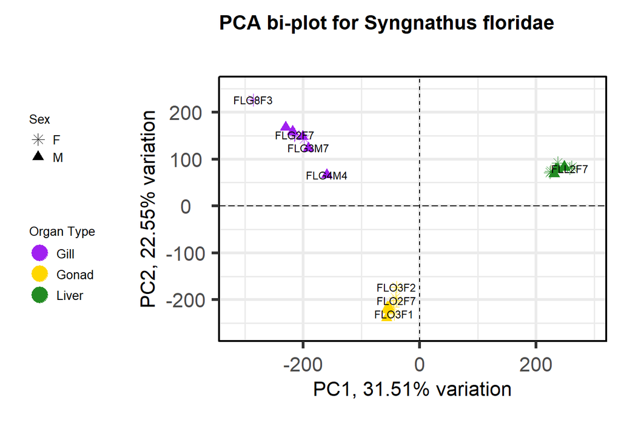

```r
#Plot the PCA
biplot(pcaFL,
       showLoadings = FALSE,
       colby = 'Organ', colkey = c('Liver'='forestgreen', 'Gill'='purple', 'Gonad'='gold'),
       colLegendTitle = "Organ Type",
       hline = 0, vline = 0,
       vlineType = 'dashed',
       pointSize = 3,
       legendPosition = 'left', legendLabSize = 10, legendIconSize = 6.0, legendTitleSize = 10,
       shape = 'Sex', shapekey = c('M'=17, 'F'=8),
       shapeLegendTitle = 'Sex',
       drawConnectors = FALSE,
       title = 'PCA bi-plot for Syngnathus floridae')
```

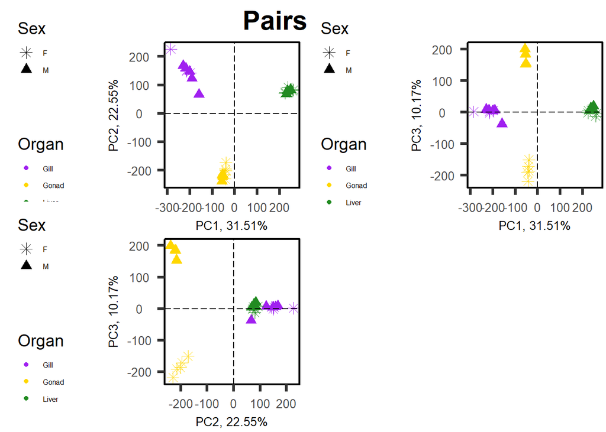

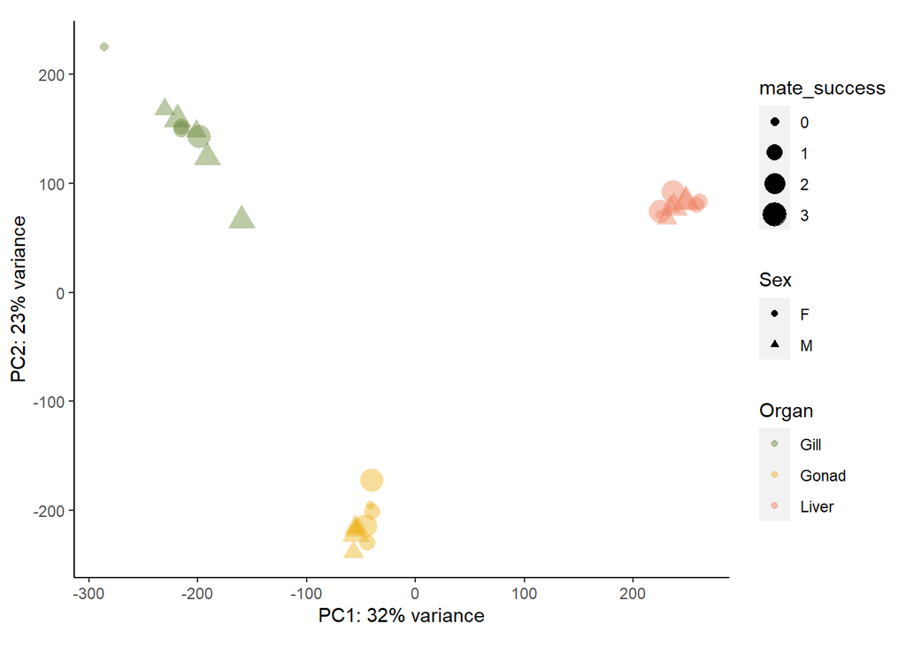

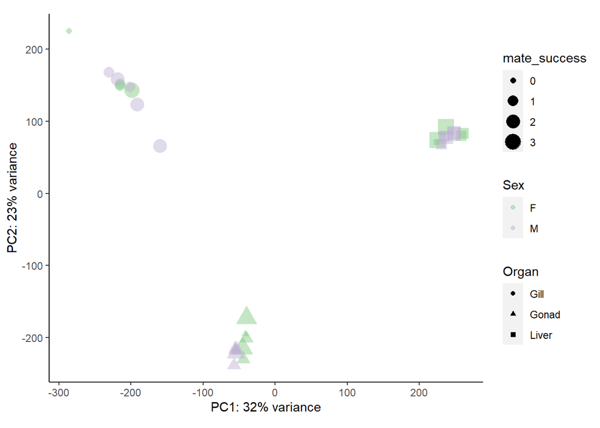

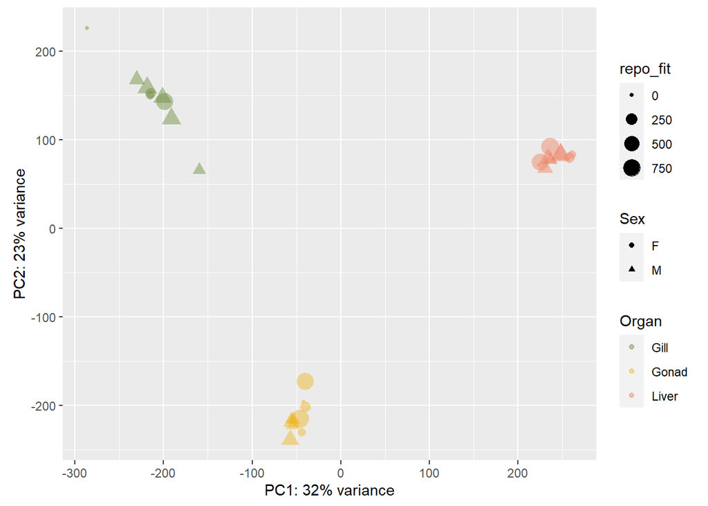

```r
pairsplot(pcaFL,
          components = getComponents(pcaFL, c(1, 2, 3)),
          triangle = FALSE,
          hline = 0, vline = 0,
          pointSize = 3,
          gridlines.major = FALSE, gridlines.minor = FALSE,
          colby = 'Organ', colkey = c('Liver'='forestgreen', 'Gill'='purple', 'Gonad'='gold'),
          shape = 'Sex', shapekey = c('M'=17, 'F'=8),
          title = 'Pairs plot', titleLabSize = 22,
          legendPosition = 'left',
          axisLabSize = 10, plotaxes = TRUE,
          margingaps = unit(c(0.1, 0.1, 0.1, 0.1), 'cm'))
```

# 2 Multifactor design - Comparing M v F across the diff tissue types

If we investigate the column data of our DESeq dataset we can see that each sample has both a sex and organ type attached to it, we will be using these two factors in our multi-factor analysis

```r
##Create a copy of the DESeq dataset
ddsMF_FL <- dds_FL

#Create an additional column the has the two conditions combined(sex and organ type)
ddsMF_FL$group <- factor(paste0(ddsMF_FL$Sex, ddsMF_FL$Organ))

#Reapply that new column as the design for this analysis
design(ddsMF_FL) <- ~ group

#Run the differential expression analysis
ddsMF_FL_exp <- DESeq(ddsMF_FL)
resultsNames(ddsMF_FL_exp)
```

```
## [1] "Intercept"             "group_FGonad_vs_FGill" "group_FLiver_vs_FGill"
## [4] "group_MGill_vs_FGill"  "group_MGonad_vs_FGill" "group_MLiver_vs_FGill"
```

## 2.1 Invesitgate the results of the differential expression

Thanks to the multi-factor analysis we can now explore differential expression between all of the different combinations:

- Male Liver v. Female Liver
- Male Gill v. Female Gill
- Male Gonad v. Female Gonad
- All of the within sex tissue comparisons (e.g. Male Liver v. Male Gill, etc.)

### M-F Liver Comparisson

```r
##Pulling out the liver M-F results with an alpha of 0.05
liver_con_res <- results(ddsMF_FL_exp, contrast = c("group", "MLiver", "FLiver"), alpha = 0.05)
liver_con_res$trin_geneid <- rownames(liver_con_res)
head(liver_con_res)
```

```
## log2 fold change (MLE): group MLiver vs FLiver
## Wald test p-value: group MLiver vs FLiver
## DataFrame with 6 rows and 7 columns
##                    baseMean log2FoldChange     lfcSE       stat    pvalue
##                   <numeric>      <numeric> <numeric>  <numeric> <numeric>
## TRINITY_DN0_c0_g1 1801.1920      0.2041304  0.202323  1.0089354 0.3130056
## TRINITY_DN0_c0_g2 2573.3828     -0.8766204  0.406703 -2.1554324 0.0311280
## TRINITY_DN0_c1_g1    9.1754      0.6472851  0.960700  0.6737642 0.5004612
## TRINITY_DN1_c0_g1 1292.0108     -0.2295744  0.160849 -1.4272665 0.1535031
## TRINITY_DN1_c0_g2  114.9169     -0.8132142  0.384337 -2.1158895 0.0343542
## TRINITY_DN1_c1_g1  611.6777     -0.0182562  0.231160 -0.0789766 0.9370513
##                        padj       trin_geneid
##                   <numeric>       <character>
## TRINITY_DN0_c0_g1  0.786487 TRINITY_DN0_c0_g1
## TRINITY_DN0_c0_g2  0.248965 TRINITY_DN0_c0_g2
## TRINITY_DN0_c1_g1  0.936374 TRINITY_DN0_c1_g1
## TRINITY_DN1_c0_g1  0.573346 TRINITY_DN1_c0_g1
## TRINITY_DN1_c0_g2  0.264271 TRINITY_DN1_c0_g2
## TRINITY_DN1_c1_g1  1.000000 TRINITY_DN1_c1_g1
```

```r
summary(liver_con_res)
```

```
##
## out of 175095 with nonzero total read count
## adjusted p-value < 0.05
## LFC > 0 (up)       : 486, 0.28%
## LFC < 0 (down)     : 1151, 0.66%
## outliers [1]       : 9783, 5.6%
## low counts [2]     : 127457, 73%
## (mean count < 7)
## [1] see 'cooksCutoff' argument of ?results
## [2] see 'independentFiltering' argument of ?results
```

There are many criteria that have been employed previously to denote sex bias. For this study we are classifying sex-biased genes as **genes with a p-value < 0.05 AND a logFC $\ge$ |2|**. With that criteria in the liver there are 173 male-biased genes and 612 female-biased genes.

I have then pulled out all of the male-biased, female-biased, and non-biased genes based on the criteria outlined above. I determined non-biased genes as a p-vaule > 0.05.

```r
#Removing the rows where padj. is NA in results
liver_con_res_noNA <- liver_con_res[!is.na(liver_con_res$padj),]
summary(liver_con_res_noNA) #We can now see that there are no outliers or low counts since the NAs have been removed
```

```
##
## out of 37855 with nonzero total read count
## adjusted p-value < 0.05
## LFC > 0 (up)       : 486, 1.3%
## LFC < 0 (down)     : 1151, 3%
## outliers [1]       : 0, 0%
## low counts [2]     : 0, 0%
## (mean count < 7)
## [1] see 'cooksCutoff' argument of ?results
## [2] see 'independentFiltering' argument of ?results
```

```r
#Creating a vector that contains all of the male-biased and female-biased genes in the liver
liver_mal_biased <- liver_con_res_noNA[which(liver_con_res_noNA$log2FoldChange >= 2 & liver_con_res_noNA$padj <= 0.05),]
liver_fem_biased <- liver_con_res_noNA[which(liver_con_res_noNA$log2FoldChange <= -2 & liver_con_res_noNA$padj <= 0.05),]

#Creating an object that contains all of the non-biased genes in the liver
liver_non_biased <- liver_con_res_noNA[which(liver_con_res_noNA$padj > 0.05),]
```

I will be generating a table that outlines the genes that are the most male or female biased in each organ type. To do this I need to pull the top 50 differentially expressed genes in males or females, get the Trinity gene IDs and then BLAST the corresponding sequences. Here I am pulling out the Trinity gene IDs for those genes.

```r
#Creating a subset of the results where the p-value is less than 0.05
liver_con_res_p05 <- liver_con_res_noNA[liver_con_res_noNA$padj <= 0.05, ]


#Pulling the top 50 diff expressed genes in Males
top50_MLiver_trin_genes <- cbind(rownames(head(liver_con_res_p05[order(liver_con_res_p05$log2FoldChange, decreasing = TRUE),], n=50)))
write.table(top50_MLiver_trin_genes,
            'FL_maleL_top50TRgenes.txt',
            sep = "",
            quote=FALSE,
            row.names = FALSE,
            col.names = FALSE)

#Pulling the top 50 diff expressed genes in Females
top50_Fliver_trin_genes <- cbind(rownames(head(liver_con_res_p05[order(liver_con_res_p05$log2FoldChange, decreasing = FALSE),], n=50)))
write.table(top50_Fliver_trin_genes,
            'FL_femL_top50TRgenes.txt',
            sep = "",
            quote=FALSE,
            row.names = FALSE,
            col.names = FALSE)
```

### M-F Gill Comparisson

```r
##Pulling out the gill M-F results
gill_con_res <- results(ddsMF_FL_exp, contrast = c("group", "MGill", "FGill"), alpha = 0.5)
gill_con_res$trin_geneid <- rownames(gill_con_res)
head(gill_con_res)
```

```
## log2 fold change (MLE): group MGill vs FGill
## Wald test p-value: group MGill vs FGill
## DataFrame with 6 rows and 7 columns
##                    baseMean log2FoldChange     lfcSE       stat    pvalue
##                   <numeric>      <numeric> <numeric>  <numeric> <numeric>
## TRINITY_DN0_c0_g1 1801.1920     -0.0589395  0.211646 -0.2784810  0.780643
## TRINITY_DN0_c0_g2 2573.3828     -0.2147873  0.426754 -0.5033053  0.614750
## TRINITY_DN0_c1_g1    9.1754      0.3328566  0.780826  0.4262878  0.669898
## TRINITY_DN1_c0_g1 1292.0108      0.0759211  0.168150  0.4515081  0.651623
## TRINITY_DN1_c0_g2  114.9169     -0.0236673  0.381089 -0.0621044  0.950480
## TRINITY_DN1_c1_g1  611.6777      0.2165980  0.230808  0.9384339  0.348021
##                        padj       trin_geneid
##                   <numeric>       <character>
## TRINITY_DN0_c0_g1         1 TRINITY_DN0_c0_g1
## TRINITY_DN0_c0_g2         1 TRINITY_DN0_c0_g2
## TRINITY_DN0_c1_g1         1 TRINITY_DN0_c1_g1
## TRINITY_DN1_c0_g1         1 TRINITY_DN1_c0_g1
## TRINITY_DN1_c0_g2         1 TRINITY_DN1_c0_g2
## TRINITY_DN1_c1_g1         1 TRINITY_DN1_c1_g1
```

```r
summary(gill_con_res)
```

```
##
## out of 175095 with nonzero total read count
## adjusted p-value < 0.5
## LFC > 0 (up)       : 337, 0.19%
## LFC < 0 (down)     : 101, 0.058%
## outliers [1]       : 9783, 5.6%
## low counts [2]     : 106353, 61%
## (mean count < 3)
## [1] see 'cooksCutoff' argument of ?results
## [2] see 'independentFiltering' argument of ?results
```

In the gills there were 78 genes that we can consider male-biased and 21 female-biased genes based on our criteria for sex-bias.

I have then pulled out all of the male-biased, female-biased, and non-biased genes to save them into their own objects.

```r
#Removing the rows where padj. is NA in results
gill_con_res_noNA <- gill_con_res[!is.na(gill_con_res$padj), ]
summary(gill_con_res_noNA) #We can now see that there are no outliers or low counts since the NAs have been removed
```

```
##
## out of 58959 with nonzero total read count
## adjusted p-value < 0.5
## LFC > 0 (up)       : 337, 0.57%
## LFC < 0 (down)     : 101, 0.17%
## outliers [1]       : 0, 0%
## low counts [2]     : 0, 0%
## (mean count < 3)
## [1] see 'cooksCutoff' argument of ?results
## [2] see 'independentFiltering' argument of ?results
```

```r
#Creating a vector that contains all of the male-biased and female-biased genes in the gills
gill_mal_biased <- gill_con_res_noNA[which(gill_con_res_noNA$log2FoldChange >= 2 & gill_con_res_noNA$padj <= 0.05),]
gill_fem_biased <- gill_con_res_noNA[which(gill_con_res_noNA$log2FoldChange <= -2 & gill_con_res_noNA$padj <= 0.05),]

#Creating an object that contains all of the non-biased genes in the gills, p>0.05
gill_non_biased <- gill_con_res_noNA[which(gill_con_res_noNA$padj > 0.05),]
```

Here I am getting the trinity gene IDs that correspond to the top 50 differentially expressed genes for males and females. Because there are only 21 female-biased genes I will only use those.

```r
#Creating a subset of results where p-value is less than 0.05
gill_con_res_p05 <- gill_con_res_noNA[gill_con_res_noNA$padj <= 0.05,]

#Pulling the top 50 diff expressed genes in Males
top50_MGill_trin_genes <- cbind(rownames(head(gill_con_res_p05[order(gill_con_res_p05$log2FoldChange, decreasing = TRUE),], n=50)))
write.table(top50_MGill_trin_genes,
            'FL_maleG_top50TRgenes.txt',
            sep = "",
            quote=FALSE,
            row.names = FALSE,
            col.names = FALSE)

#Pulling the top 21 diff expressed genes in Females - Only 21 female-biased genes in the gills
top21_FGill_trin_genes <- cbind(rownames(head(gill_con_res_p05[order(gill_con_res_p05$log2FoldChange, decreasing = FALSE),], n=21)))
write.table(top21_FGill_trin_genes,
            'FL_femG_top21TRgenes.txt',
            sep = "",
            quote=FALSE,
            row.names = FALSE,
            col.names = FALSE)
```

### M-F Gonad Comparisson

```r
##Pulling out the gonad M-F results
gonad_con_res <- results(ddsMF_FL_exp, contrast = c("group", "MGonad", "FGonad"), alpha = 0.05)
gonad_con_res$trin_geneid <- rownames(gonad_con_res)
head(gonad_con_res)
```

```
## log2 fold change (MLE): group MGonad vs FGonad
## Wald test p-value: group MGonad vs FGonad
## DataFrame with 6 rows and 7 columns
##                    baseMean log2FoldChange     lfcSE      stat      pvalue
##                   <numeric>      <numeric> <numeric> <numeric>   <numeric>
## TRINITY_DN0_c0_g1 1801.1920       0.721035  0.200089   3.60356 0.000313886
## TRINITY_DN0_c0_g2 2573.3828       1.167179  0.401912   2.90407 0.003683505
## TRINITY_DN0_c1_g1    9.1754       2.019142  0.779584   2.59002 0.009596920
## TRINITY_DN1_c0_g1 1292.0108      -0.323475  0.158724  -2.03797 0.041553251
## TRINITY_DN1_c0_g2  114.9169       0.630921  0.374468   1.68485 0.092017708
## TRINITY_DN1_c1_g1  611.6777      -0.771963  0.219801  -3.51210 0.000444575
##                         padj       trin_geneid
##                    <numeric>       <character>
## TRINITY_DN0_c0_g1 0.00226969 TRINITY_DN0_c0_g1
## TRINITY_DN0_c0_g2 0.01945037 TRINITY_DN0_c0_g2
## TRINITY_DN0_c1_g1 0.04366509 TRINITY_DN0_c1_g1
## TRINITY_DN1_c0_g1 0.14088558 TRINITY_DN1_c0_g1
## TRINITY_DN1_c0_g2 0.25510168 TRINITY_DN1_c0_g2
## TRINITY_DN1_c1_g1 0.00309137 TRINITY_DN1_c1_g1
```

```r
summary(gonad_con_res)
```

```
##
## out of 175095 with nonzero total read count
## adjusted p-value < 0.05
## LFC > 0 (up)       : 12030, 6.9%
## LFC < 0 (down)     : 7435, 4.2%
## outliers [1]       : 9783, 5.6%
## low counts [2]     : 79387, 45%
## (mean count < 1)
## [1] see 'cooksCutoff' argument of ?results
## [2] see 'independentFiltering' argument of ?results
```

Between the ovaries and testis (gonads) there were 8907 genes that we can consider male-biased and 3950 female-biased genes based on our criteria for sex-bias.

From the gonad M-F results I have then pulled out all of the male-biased, female-biased, and non-biased genes and saved them to their own objects.

```r
#Removing the rows where padj. is NA in results
gonad_con_res_noNA <- gonad_con_res[!is.na(gonad_con_res$padj), ]
summary(gonad_con_res_noNA) #We can now see that there are no outliers or low counts since the NAs have been removed
```

```
##
## out of 85925 with nonzero total read count
## adjusted p-value < 0.05
## LFC > 0 (up)       : 12030, 14%
## LFC < 0 (down)     : 7435, 8.7%
## outliers [1]       : 0, 0%
## low counts [2]     : 0, 0%
## (mean count < 1)
## [1] see 'cooksCutoff' argument of ?results
## [2] see 'independentFiltering' argument of ?results
```

```r
#Creating an object that contains all of the male-biased and female-biased genes in the gonads
gonad_mal_biased <- gonad_con_res_noNA[which(gonad_con_res_noNA$log2FoldChange >= 2 & gonad_con_res_noNA$padj <= 0.05),]
gonad_fem_biased <- gonad_con_res_noNA[which(gonad_con_res_noNA$log2FoldChange <= -2 & gonad_con_res_noNA$padj <= 0.05),]

#Creating an object that contains all of the non-biased genes in the gonads, p>0.05
gonad_non_biased <- gonad_con_res_noNA[which(gonad_con_res_noNA$padj > 0.05),]
```

I then pulled out the trinity gene IDs that corresponded to the top 50 differentially expressed genes in males and females so that I could BLAST the sequences.

```r
#Creating a subset of the results where the p-value is less than 0.05
gonad_con_res_p05 <- gonad_con_res_noNA[gonad_con_res_noNA$padj <= 0.05,]

#Pulling the top 50 diff expressed genes in Males
top50_MGonad_trin_genes <- cbind(rownames(head(gonad_con_res_p05[order(gonad_con_res_p05$log2FoldChange, decreasing = TRUE),], n=50)))
write.table(top50_MGonad_trin_genes,
            'FL_maleGon_top50TRgenes.txt',
            sep = "",
            quote=FALSE,
            row.names = FALSE,
            col.names = FALSE)

#Pulling the top 50 diff expressed genes in Females
top50_FGonad_trin_genes <- cbind(rownames(head(gonad_con_res_p05[order(gonad_con_res_p05$log2FoldChange, decreasing = FALSE),], n=50)))
write.table(top50_FGonad_trin_genes,
            'FL_femGon_top50TRgenes.txt',
            sep = "",
            quote=FALSE,
            row.names = FALSE,
            col.names = FALSE)
```

### MA Plots

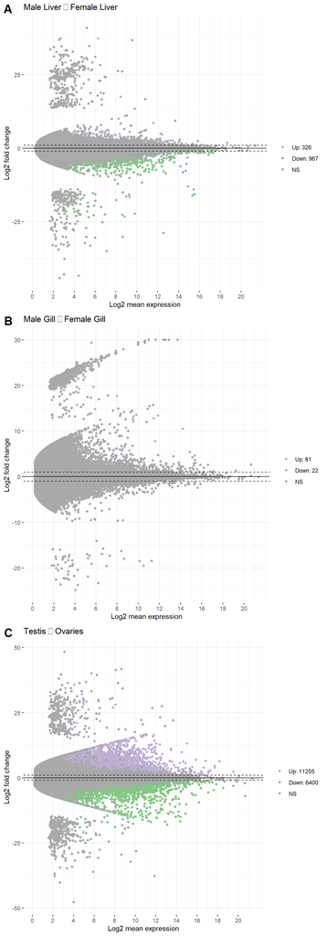

## 2.2 Creating an Upset Plot

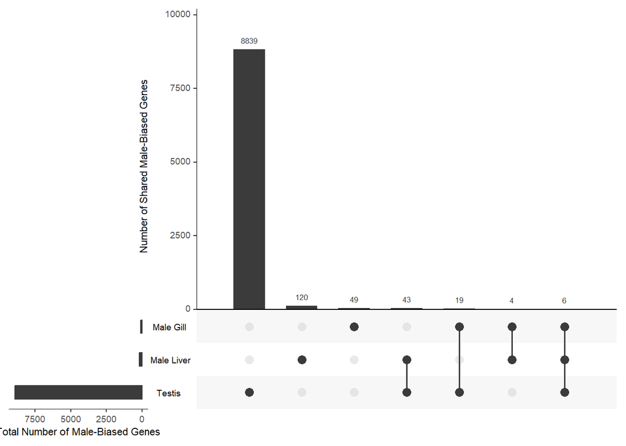

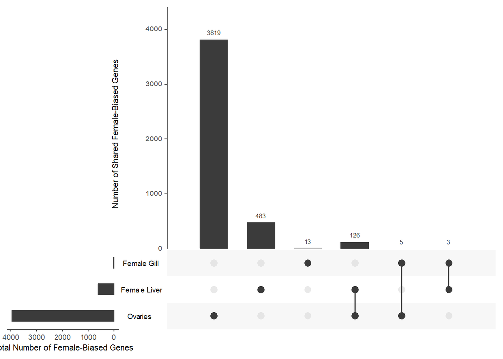

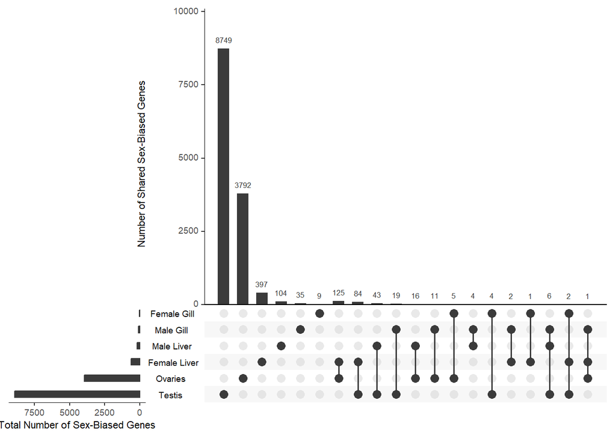

## 2.3 Variation in FC across sex-bias and tissue type

I want to create a plot the highlights the variation we see in fold-change both across the different biases groups (male-biased, female-biased, and non-biased) within one tissue type and across all of the tissue types. To do this I first need to create a “long” dataset in the following format:

| Tissue_type | Bias | Fold-Change |
| --- | --- | --- |
| Gill | male_bias | XXXXX |
| Gill | male_bias | XXXXX |
| Gill | fem_bias | XXXXX |
| Gill | no_bias | XXXXX |
| … | …. | … |
| Liver | male_bias | XXXXX |
| Liver | male_bias | XXXXX |
| Liver | fem_bias | XXXXX |
| Liver | no_bias | XXXXX |
| … | …. | … |
| Gonad | male_bias | XXXXX |
| Gonad | male_bias | XXXXX |
| Gonad | fem_bias | XXXXX |
| Gonad | no_bias | XXXXX |
| … | …. | … |

That dataset is created here, with the Trinity gene IDs included as well:

```r
logFC_long<- data.frame(
  tissue=c(rep("Gill",nrow(gill_fem_biased)),
           rep("Gill", nrow(gill_mal_biased)),
           rep("Gill", nrow(gill_non_biased)),
           rep("Gonad", nrow(gonad_fem_biased)),
           rep("Gonad", nrow(gonad_mal_biased)),
           rep("Gonad", nrow(gonad_non_biased)),
           rep("Liver", nrow(liver_fem_biased)),
           rep("Liver", nrow(liver_mal_biased)),
           rep("Liver", nrow(liver_non_biased))
         ),
  bias=c(rep("FB",nrow(gill_fem_biased)),
         rep("MB",nrow(gill_mal_biased)),
         rep("NB", nrow(gill_non_biased)),
         rep("FB", nrow(gonad_fem_biased)),
         rep("MB", nrow(gonad_mal_biased)),
         rep("NB", nrow(gonad_non_biased)),
         rep("FB", nrow(liver_fem_biased)),
         rep("MB", nrow(liver_mal_biased)),
         rep("NB", nrow(liver_non_biased))
         ),
  logFC=c(gill_fem_biased$log2FoldChange,
          gill_mal_biased$log2FoldChange,
          gill_non_biased$log2FoldChange,
          gonad_fem_biased$log2FoldChange,
          gonad_mal_biased$log2FoldChange,
          gonad_non_biased$log2FoldChange,
          liver_fem_biased$log2FoldChange,
          liver_mal_biased$log2FoldChange,
          liver_non_biased$log2FoldChange
          ),
  geneID=c(rownames(gill_fem_biased),
           rownames(gill_mal_biased),
           rownames(gill_non_biased),
           rownames(gonad_fem_biased),
           rownames(gonad_mal_biased),
           rownames(gonad_non_biased),
           rownames(liver_fem_biased),
           rownames(liver_mal_biased),
           rownames(liver_non_biased)
           )

)
```

With the dataset in the proper format now, we can generate the plot

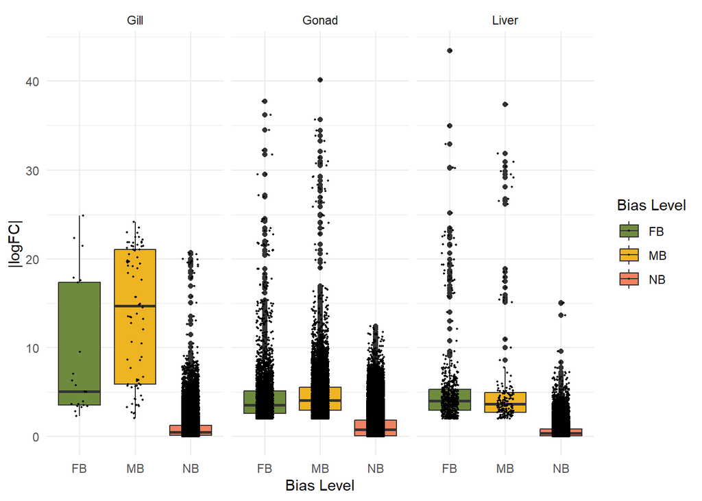

There appears to be differences in the logFC across both the organs and the sex-bias groups (male-biased, fem-biased, and non-biased). Let’s explore some analyses to see if we can put some statistical power behind those differences.

```r
#Looking at some summary statistics for logFC between the different groups
tapply(abs(logFC_long$logFC), list(logFC_long$bias, logFC_long$tissue), mean)
```

```
##         Gill    Gonad     Liver
## FB  9.065314 4.375996 5.2669169
## MB 13.746325 4.651548 6.1082338
## NB  0.889900 1.233968 0.6360315
```

```r
tapply(abs(logFC_long$logFC), list(logFC_long$bias, logFC_long$tissue), sd)
```

```
##        Gill    Gonad     Liver
## FB 7.577071 3.001957 4.7115646
## MB 7.347919 2.594089 7.0556684
## NB 1.128376 1.423840 0.7944389
```

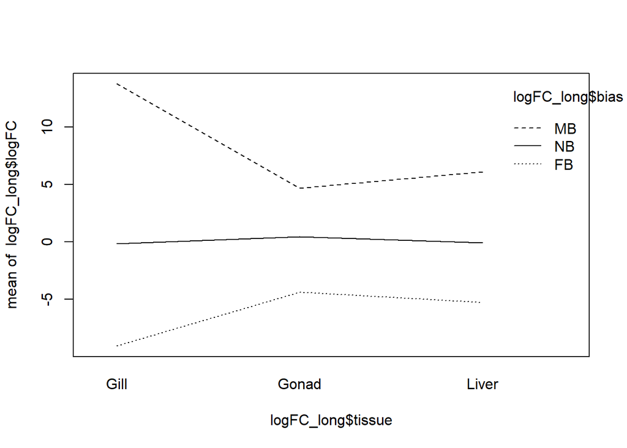

```r
par(mfrow=c(1,1))
interaction.plot(logFC_long$tissue, logFC_long$bias, logFC_long$logFC)
```

```r
logFC_long$tissue <- as.factor(logFC_long$tissue)
logFC_long$bias <- as.factor(logFC_long$bias)

fc_var_aov <- aov(abs(logFC_long$logFC) ~ logFC_long$bias*logFC_long$tissue)
anova(fc_var_aov)
```

|  | Df | Sum Sq | Mean Sq | F value | Pr(>F) |
| --- | --- | --- | --- | --- | --- |
| logFC_long$bias | 2 | 173722.443 | 86861.221475 | 42826.377 | 0 |
| logFC_long$tissue | 2 | 7507.055 | 3753.527678 | 1850.653 | 0 |
| logFC_long$bias:logFC_long$tissue | 4 | 9112.751 | 2278.187740 | 1123.246 | 0 |
| Residuals | 175266 | 355477.626 | 2.028218 | NA | NA |

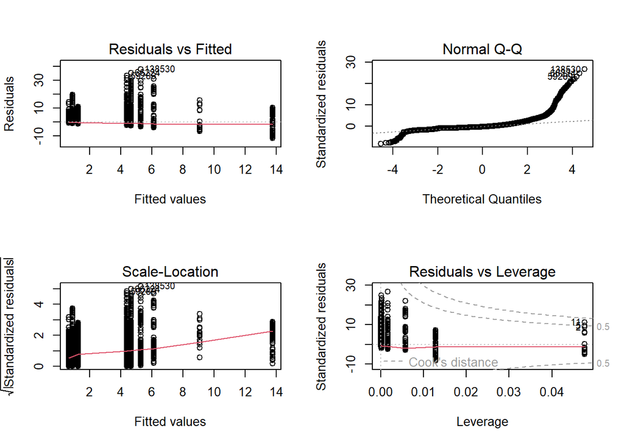

```r
par(mfrow = c(2,2))
plot(fc_var_aov)
```

```r
library(car)
leveneTest(fc_var_aov)
```

|  | Df | F value | Pr(>F) |
| --- | --- | --- | --- |
| group | 8 | 1977.072 | 0 |
|  | 175266 | NA | NA |

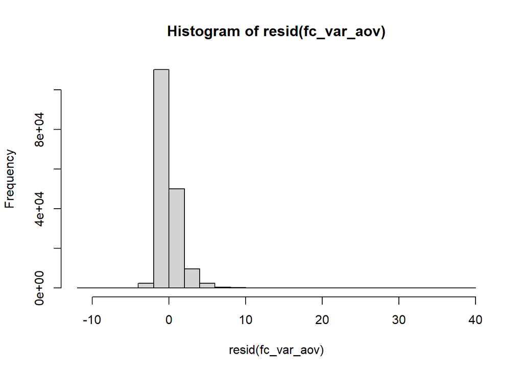

```r
par(mfrow=c(1,1))
hist(resid(fc_var_aov))
```

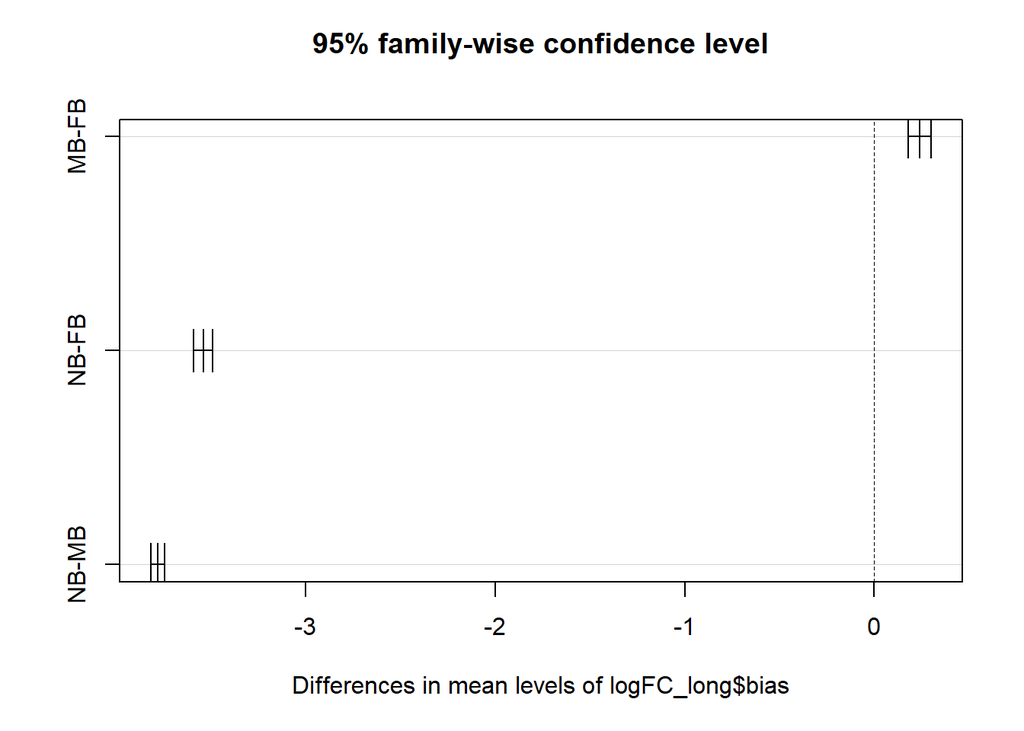

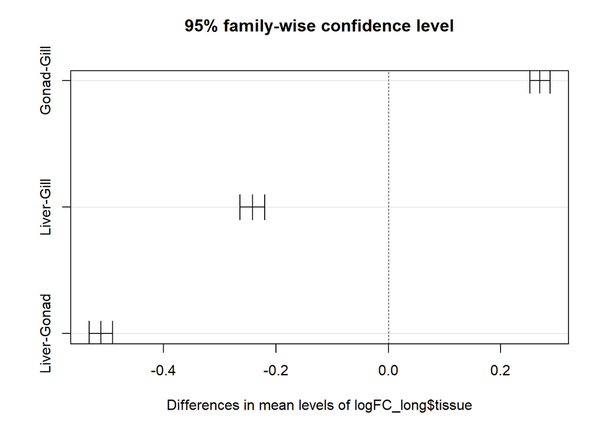

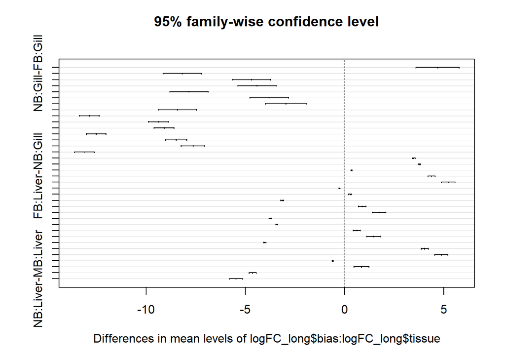

```r
#shapiro.test(resid(fc_var_aov))

plot(TukeyHSD(fc_var_aov))
```

```r
library(multcompView)
multcompLetters4(fc_var_aov, TukeyHSD(fc_var_aov))
```

```
## $`logFC_long$bias`
##  MB  FB  NB
## "a" "b" "c"
##
## $`logFC_long$tissue`
## Gonad  Gill Liver
##   "a"   "b"   "c"
##
## $`logFC_long$bias:logFC_long$tissue`
##  MB:Gill  FB:Gill MB:Liver FB:Liver MB:Gonad FB:Gonad NB:Gonad  NB:Gill
##      "a"      "b"      "c"      "d"      "e"      "f"      "g"      "h"
## NB:Liver
##      "i"
```

## 2.4 Categorizing sex-specific genes

Now that we have investigated what the sex-bias is like across the different tissue types I want to dive further into genes with **sex-specific expression**. These are genes expressed only in one sex or the other. I am classifying a sex-specific genes within each tissue as ones where the expression of that gene is 0 for all of one sex and there is a median of $\ge 10$ in the other sex.

```r
#Create a vector with the different organ types
organs <- levels(colData(dds_FL)$Organ)

#Create an empty list to store my datasets in
FL_sex_specific_genes <- list()

#Generate the for loop to identify MSpecific and FSpecific genes in each organ based on Medians
for(organ in organs){

  #Male-Specific Genes
  ##Pull out all of the rows where fem count = 0
  fem0_organ <- assay(dds_FL)[rowSums(assay(dds_FL)[, dds_FL$Sex == "F" & dds_FL$Organ==organ]) < 1, dds_FL$Organ == organ]

  ##Pull out rows where median of male count >=10 for that organ
  mal10_organ <- apply(assay(dds_FL)[, dds_FL$Sex == "M" & dds_FL$Organ == organ],
                       1,
                       function(x) median(x) >=10)

  ##Keep only the rows where fem=0 and the Male median>=10
  fem0_mal10_organ <- fem0_organ[rownames(fem0_organ) %in% names(mal10_organ[mal10_organ == TRUE]),]

  ##Create a new object with a name based on the organ type
  organ_malsp <- sub("$", "_male_specific", organ)
  FL_sex_specific_genes[[organ_malsp]] <- fem0_mal10_organ



  #Female-Specific Genes
  ##Pull out all of the rows where male count = 0
  mal0_organ <- assay(dds_FL)[rowSums(assay(dds_FL)[, dds_FL$Sex == "M" & dds_FL$Organ==organ]) < 1, dds_FL$Organ == organ]

  ##Pull out rows where median of female count >=10 for that organ
  fem10_organ <- apply(assay(dds_FL)[, dds_FL$Sex == "F" & dds_FL$Organ == organ],
                       1,
                       function(x) median(x) >=10)

  #Keep only the rows where male=0 and the fem median>=10
  mal0_fem10_organ <- mal0_organ[rownames(mal0_organ) %in% names(fem10_organ[fem10_organ == TRUE]),]

  # Create a new object with a name based on the organ type
  organ_femsp <- sub("$", "_female_specific", organ)
  FL_sex_specific_genes[[organ_femsp]] <- mal0_fem10_organ
}
```

```r
# the one to try - for individual thresholds
#fem0_gill<-assay(dds_FL)[rowSums(assay(dds_FL)[,dds_FL$Sex == "F"]) < 1 ,dds_FL$Organ == "Gill"]
#malLots_gill<-which(rowSums(t(apply(assay(dds_FL)[,dds_FL$Sex == "M" & dds_FL$Organ == "Gill"],1,function(x) x>=3)))==ncol(assay(dds_FL)[,dds_FL$Sex == "M" & dds_FL$Organ == "Gill"]))
#fem0_malLots_gill<-fem0_gill[rownames(fem0_gill) %in% names(malLots_gill),]
```

### 2.4.1 Investigating the results of the sex-specific subsetting

Let’s now take a look at how many sex-specific genes we have in each tissue type:

Sex-specific Genes

| Tissue Type | Sex | Number of Sex-specific Genes |
| --- | --- | --- |
| Gill | F | 42 |
| Gill | M | 33 |
| Gonad | F | 439 |
| Gonad | M | 885 |
| Liver | F | 13 |
| Liver | M | 5 |

To get a better idea what is going on between the sex-specific genes vs the sex-biased genes I first determined how many overlaps there were between our sex-biased and sex-specific genes and then used plotCounts to plot the counts for each gene separately.

In the **Male Gills** there are 4 genes that overlap between sex-biased and sex-specific, there are 516 overlapping in the **gonads** and 0 overlapping in the **liver**. For females we have 3 overlapping sex-specific and sex-biased genes in the **gills**, 174 genes in the **gonads**, and 4 genes in the **liver**.

```r
## Female sex-specific
fem_sp_geneIDs <- rownames(FL_sex_specific_genes$Gill_female_specific)

##Set the plotting window
par(mfrow=c(1,1))

for(gene in fem_sp_geneIDs){

  plotCounts(ddsMF_FL[,ddsMF_FL$Organ == 'Gill'], gene=gene, intgroup="Sex")

}

## Female sex-biased
gill_fem_biased_geneIDS <- rownames(gill_fem_biased)

##Set the plotting window
par(mfrow=c(1,1))

for(gene in gill_fem_biased_geneIDS){

  plotCounts(ddsMF_FL[,ddsMF_FL$Organ == 'Gill'], gene=gene, intgroup="Sex", col= 'salmon', pch = 19)

}
```

## 2.5 Creating categories and binning the sex-biased genes based on degree of logFC

This binned was only done on the sex-biased genes, will not have a category for the unbiased genes. The cutoffs for the different groups are as follows:

```
1. Low - biased = LFC 2 - 3
2. Medium - biased = LFC 3 - 5
3. High - biased = LFC 5 - 10
4. Extreme sex bias = LFC > 10
```

Counts of the sex-specific genes will be added on separately as they were not classified based on fold-change but rather a presence in one sex and an absence in the other sex.

```r
#Create  subset of our long dataset that does not include the non-biased genes
logFC_long_noNB <- logFC_long[logFC_long$bias != "NB",]

#Make a vector that contains all of the groupings
biased_bins <- c("low", "med", "high", "extreme", "sex-specific")

#Create a new column in the dataset and use ifelse statements to set the category limits
#abs(logFC) was used to account for the fem-biased genes possessing negative values
logFC_long_noNB$bias_cat <- ifelse(abs(logFC_long_noNB$logFC) >= 2 & abs(logFC_long_noNB$logFC) < 3, biased_bins[1],
                                   ifelse(abs(logFC_long_noNB$logFC) >= 3 & abs(logFC_long_noNB$logFC) < 5, biased_bins[2],
                                          ifelse(abs(logFC_long_noNB$logFC) >= 5 & abs(logFC_long_noNB$logFC) < 10,
                                                 biased_bins[3],
                                                 biased_bins[4])
                                          )
                                   )

#Make a table to count the number of genes in each category for each organ
bias_cat_table <- table(logFC_long_noNB$bias, logFC_long_noNB$bias_cat, logFC_long_noNB$tissue)

#Add the counts of sex-specific genes to the table
bias_cat_gill <- cbind(bias_cat_table[,, "Gill"], "sex-specific" = c(nrow(FL_sex_specific_genes$Gill_female_specific), nrow(FL_sex_specific_genes$Gill_male_specific)))
bias_cat_gonad <- cbind(bias_cat_table[,, "Gonad"], "sex-specific" = c(nrow(FL_sex_specific_genes$Gonad_female_specific), nrow(FL_sex_specific_genes$Gonad_male_specific)))
bias_cat_liver <- cbind(bias_cat_table[,, "Liver"], "sex-specific" = c(nrow(FL_sex_specific_genes$Liver_female_specific), nrow(FL_sex_specific_genes$Liver_male_specific)))
```

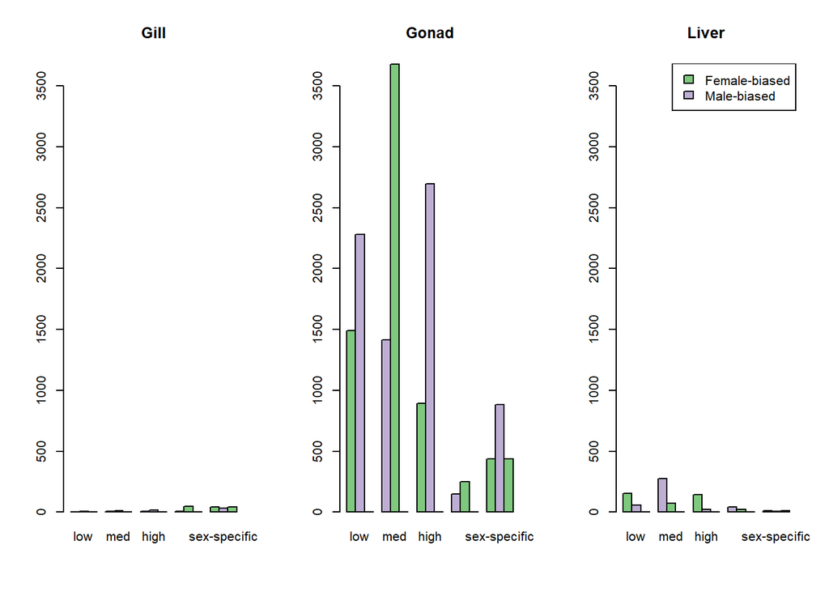

```r
#Plot the counts for each tissue type
par(mfrow=c(1, 3))
barplot(bias_cat_gill[,biased_bins], beside = TRUE, ylim = c(0, max(bias_cat_table) + 1), col = c("#7fc97f", "#beaed4"),
        main = "Gill")
barplot(bias_cat_gonad[,biased_bins], beside = TRUE, ylim = c(0, max(bias_cat_table) + 1), col = c("#7fc97f", "#beaed4"),
        main = "Gonad")
barplot(bias_cat_liver[,biased_bins], beside = TRUE, ylim = c(0, max(bias_cat_table) + 1), col = c("#7fc97f", "#beaed4"),
        main = "Liver")
legend("topright", legend = c("Female-biased", "Male-biased"), fill = c("#7fc97f", "#beaed4"))
```

## 2.6 Gene Ontology Analysis

We wanted to figure out two things:

1. What are the genes that are sex-biased within each tissue type
2. What are the GO terms for those genes.

To accomplish this I first had to pull out the sequences that corresponded to the Trinity gene IDS pulled out above. Once those sequences were fetched they were blasted against the *Syngnathus scovelli* genome. This was completed with the following bash script on the RCC.

### 2.6.1 Using BLAST in command line

```bash
#Create a BLAST database - Used Syngnathus scovelli for our BLAST database
makeblastdb -in ../ncbi_dataset/data/GCF_024217435.1/GCF_024217435.1_RoL_Ssco_1.1_genomic.fna -out s_scov_genome -dbtype nucl
```

```bash
#!/bin/bash

#Create the arguements
input_dir_TR=$1 #Location of the .txt files that contain the trinity gene IDs
subset_fasta=$2 #Path to the subset_fasta_file script
assembly_file=$3 #Name/location of the de novo assembly
blast_database=$4
output_dir=$5 #Desired output directory for .fasta and BLAST files

## Loop through all the Trinity gene ID .txt files
for file in $input_dir_TR/*TRgenes.txt
    do

    #Extract the sample name from the file name
    sample=$(basename $file .txt)

    #Get the corresponding sequences for the Trinity Gene IDs
    echo "Running subset_fasta_file for ${sample}..."
    $subset_fasta -c -f $assembly_file -l $input_dir_TR/${sample}.txt

    #Rename the automated output from the subset_fasta_file script
    fasta_out=$(basename $assembly_file fasta)
    mv $fasta_out.subset.fasta ${sample}.fasta

    #Blast the sequences
    echo "Running BLAST for ${sample}..."
    blastn -db $blast_database -query ${sample}.fasta -out ${sample}_blast.txt \
        -evalue 0.001 \
        -num_threads 12 \
        -outfmt "6 qseqid qstart qend stitle sstart send evalue bitscore length pident gaps"

    #Move the outputs into desired output directory
    mv ${sample}* $output_dir

done
```

This script was run as `bash bash_scripts/blast_pipeline.sh floridae_high_exp_genes/high_expTG_names other_scripts/subset_fasta_file trinity_supertran_floridae.fasta ../genomes/s_scov/s_scov_genome floridae_high_exp_genes/high_exp_results/`

Once the BLAST results were obtained in the RCC I read them into R for further filtering (keeping only one hit per gene)

```r
#Specify the directory where BLAST results are located
blast_path <- "data/floridae_BLAST/"

#Create a list of the files I want
FL_blast_files <- list.files(blast_path)

#Create an empty list to store my datasets in
FL_blast_list <- list()

#Create a loop to read in all of the blast results
for(file_name in FL_blast_files){
  # Read the file and store it in a new object
  file_data <- read.delim(file.path(blast_path, file_name), stringsAsFactors = FALSE, quote = "", sep = "\t", header = FALSE)

  #Add column names to the dataset
  colnames(file_data) <- c("trin_geneid", "trin_gene_start", "trin_gene_end", "scov_gene_info", "scov_gene_start", "scov_gene_end", "evalue", "bit_score", "length", "pident", "gaps")

  # Create a new object with a name based on the file name
  blast_name <- sub(".txt$", "", file_name) #Removes the file extension
  FL_blast_list[[blast_name]] <- file_data
}
```

### 2.6.2 Filtering Blast results

Because of the way BLAST was run in the RCC, we can have multiple hits for one gene, I want to filter that out so that there is only one hit kept for each gene.

```r
#Use lapply to apply the function to each dataset stored in the list created above
blast_output_filtered <- lapply(FL_blast_list, function(data_frame){

  #Pull out the Unique Trinity gene IDs
  uniqueID <- unique(data_frame[1])

  #Create an empty dataframe to store intermediate results in
  output <- data.frame(matrix(data = NA, ncol = ncol(data_frame), nrow = 0))
  colnames(output) <- c("trin_geneid", "trin_gene_start", "trin_gene_end", "scov_gene_info", "scov_gene_start", "scov_gene_end", "evalue", "bit_score", "length", "pident", "gaps")

  #Generate a for loop that pulls out the lowest e-value + highest % identity for each gene
  for(gene in uniqueID$trin_geneid){

    #Subset the dataset for each Trinity gene
    this_trin_gene<- subset(data_frame, trin_geneid==gene)
    #Pull out gene with smallest e-value
    uni_gene_subset_lowe <- this_trin_gene[which(this_trin_gene$evalue == min(this_trin_gene$evalue)),]
    #In case mult. genes have same e-value, pull out gene with highest % identity
    uni_gene_subset_lowe_highpid <- uni_gene_subset_lowe[which(uni_gene_subset_lowe$pident == max(uni_gene_subset_lowe$pident)),]

    # keep only one of multiple identical rows
    uni_gene_subset_lowe_highpid <- unique(uni_gene_subset_lowe_highpid)

    # check that there is a single gene ID in scovelli, if not, only first row is kept
    if(length(gsub("^.*(GeneID:\\d+)\\].*$","\\1",uni_gene_subset_lowe_highpid$scov_gene_info))>1){
    #   browser()
    # } else{
      uni_gene_subset_lowe_highpid<-uni_gene_subset_lowe_highpid[1,]
    }

    #Add the final gene into the empty dataframe from above
    output <- rbind(output, uni_gene_subset_lowe_highpid)
  }

  return(output)
})
```

### 2.6.3 Merging the BLAST filtered Data frames with the sex-biased information

Not all of the trinity genes had a BLAST hit come back, but I still want to include what those genes are in the dataset. To do this I am merging all of the top 50 genes with the filtered BLAST dataset and if there are genes that did not have any hits (i.e. are not in the filtered BLAST database) then they will receive an “NA”.

All genes that had an “NA” come back from blasting against the *S. scovelli* database will be blasted against the non-redundant BLAST database as well.

```r
#Getting the top 50 diff. expressed genes in Males
top50_MGonad <- head(gonad_con_res_p05[order(gonad_con_res_p05$log2FoldChange, decreasing = TRUE),],
                     n=50)
top50_MGill <- head(gill_con_res_p05[order(gill_con_res_p05$log2FoldChange, decreasing = TRUE),],
                     n=50)
top50_MLiver <- head(liver_con_res_p05[order(liver_con_res_p05$log2FoldChange, decreasing = TRUE),],
                     n=50)

#Pulling the top 50 diff expressed genes in Females
top50_FGonad <- head(gonad_con_res_p05[order(gonad_con_res_p05$log2FoldChange, decreasing = FALSE),],
                     n=50)
top21_FGill <- head(gill_con_res_p05[order(gill_con_res_p05$log2FoldChange, decreasing = FALSE),],
                     n=21)
top50_FLiver <- head(liver_con_res_p05[order(liver_con_res_p05$log2FoldChange, decreasing = FALSE),],
                     n=50)
#Create dataframes for all of the above that contains the trinity gene ID and the logFoldChange
top50_MGonad_df <- as.data.frame(cbind(trin_geneid = top50_MGonad$trin_geneid,
                                       LogFC = top50_MGonad$log2FoldChange))
top50_MGill_df <- as.data.frame(cbind(trin_geneid = top50_MGill$trin_geneid,
                                       LogFC = top50_MGill$log2FoldChange))
top50_MLiver_df <- as.data.frame(cbind(trin_geneid = top50_MLiver$trin_geneid,
                                       LogFC = top50_MLiver$log2FoldChange))
top50_FGonad_df <- as.data.frame(cbind(trin_geneid = top50_FGonad$trin_geneid,
                                      LogFC = top50_FGonad$log2FoldChange))
top21_FGill_df <- as.data.frame(cbind(trin_geneid = top21_FGill$trin_geneid,
                                      LogFC = top21_FGill$log2FoldChange))
top50_FLiver_df <- as.data.frame(cbind(trin_geneid = top50_FLiver$trin_geneid,
                                      LogFC = top50_FLiver$log2FoldChange))

#Merge the above dataframes with the corresponding blast_output_filtered dataframe
blast_output_filtered$FL_femG_top21TRgenes_blast <- merge(top21_FGill_df, blast_output_filtered$FL_femG_top21TRgenes_blast, by = "trin_geneid", all.x = TRUE, all.y = TRUE)
blast_output_filtered$FL_femGon_top50TRgenes_blast <- merge(top50_FGonad_df, blast_output_filtered$FL_femGon_top50TRgenes_blast, by = "trin_geneid", all.x = TRUE, all.y = TRUE)
blast_output_filtered$FL_femL_top50TRgenes_blast <- merge(top50_FLiver_df, blast_output_filtered$FL_femL_top50TRgenes_blast, by = "trin_geneid", all.x = TRUE, all.y = TRUE)
blast_output_filtered$FL_maleG_top50TRgenes_blast <- merge(top50_MGill_df, blast_output_filtered$FL_maleG_top50TRgenes_blast, by = "trin_geneid", all.x = TRUE, all.y = TRUE)
blast_output_filtered$FL_maleGon_top50TRgenes_blast <- merge(top50_MGonad_df, blast_output_filtered$FL_maleGon_top50TRgenes_blast, by = "trin_geneid", all.x = TRUE, all.y = TRUE)
blast_output_filtered$FL_maleL_top50TRgenes_blast <- merge(top50_MLiver_df, blast_output_filtered$FL_maleL_top50TRgenes_blast, by = "trin_geneid", all.x = TRUE, all.y = TRUE)
```